# An R Markdown Document

Li Lei

Han Meimei

2016/06/27

A bit *introduction* here. We no longer need to start an article by writing this:

```latex
\documentclass{article}
\begin{document}
\end{document}
```

# Start with a cool section

You can use traditional **Markdown** syntax, such as [links](http://yihui.name/knitr) and `code`. Here is a quote:

> A girl phoned me the other day and said “Come on over, there’s nobody home.” I went over. Nobody was home. – Rodney Dangerfield

# Followed by another section

Of course you can write lists:

- apple
- pear
- banana

Or ordered lists:

1. items
2. will
3. be
4. ordered
   - nested
   - items

# Okay, some R code

```r
fit = lm(dist ~ speed + I(speed^2), data = cars)
b = coef(fit)  # coefficients
summary(fit)
```

```
##
## Call:
## lm(formula = dist ~ speed + I(speed^2), data = cars)
##
## Residuals:
##     Min      1Q  Median      3Q     Max
## -28.720  -9.184  -3.188   4.628  45.152
##
## Coefficients:
##             Estimate Std. Error t value Pr(>|t|)
## (Intercept)  2.47014   14.81716   0.167    0.868
## speed        0.91329    2.03422   0.449    0.656
## I(speed^2)   0.09996    0.06597   1.515    0.136
##
## Residual standard error: 15.18 on 47 degrees of freedom
## Multiple R-squared:  0.6673, Adjusted R-squared:  0.6532
## F-statistic: 47.14 on 2 and 47 DF,  p-value: 5.852e-12
```

The code will be highlighted in all output formats.

# And some pictures

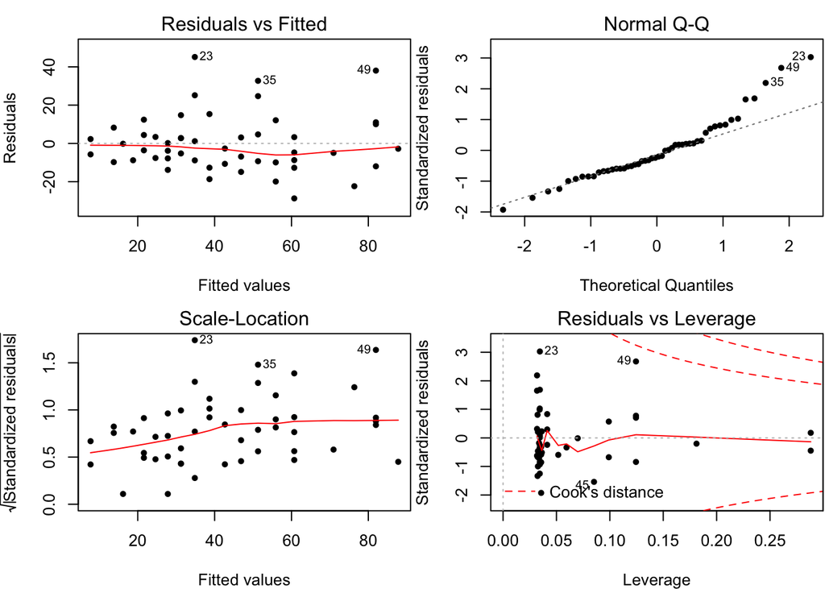

Regression diagnostics

```r
par(mfrow = c(2, 2), pch = 20, mar = c(4, 4, 2, .1), bg = 'white')
plot(fit)
```

# A little bit math

$$Y = \beta_0 + \beta_1 x + \epsilon$$

# Pandoc extension: definition lists

**Programmer**

A programmer is the one who turns coffee into code.

**LaTeX**

A simple tool that is nothing but a couple of backslashes.

# Pandoc extension: examples

We have some examples.

1. Think what is `0.3 + 0.4 - 0.7`. Zero. Easy.
2. Now think what is `0.3 - 0.7 + 0.4`. Still zero?

People are often surprised by (2).

# Pandoc extension: tables

A table here.

Demonstration of simple table syntax.

| Right | Left | Center | Default |
| --- | --- | --- | --- |
| 12 | 12 | 12 | 12 |
| 123 | 123 | 123 | 123 |
| 1 | 1 | 1 | 1 |

You can also generate tables easily using `knitr::kable()` or the **pander** package.

```r
knitr::kable(head(iris))
```

| Sepal.Length | Sepal.Width | Petal.Length | Petal.Width | Species |
| --- | --- | --- | --- | --- |
| 5.1 | 3.5 | 1.4 | 0.2 | setosa |
| 4.9 | 3.0 | 1.4 | 0.2 | setosa |
| 4.7 | 3.2 | 1.3 | 0.2 | setosa |
| 4.6 | 3.1 | 1.5 | 0.2 | setosa |
| 5.0 | 3.6 | 1.4 | 0.2 | setosa |
| 5.4 | 3.9 | 1.7 | 0.4 | setosa |

# Pandoc extension: footnotes

We can also write footnotes[^1].

Or write some inline footnotes[^2].

# Pandoc extension: citations

We compile the R Markdown file to Markdown through **knitr** (Xie 2015) in R (R Core Team 2016). For more about Xie (2015), see http://yihui.name/knitr.

# References

R Core Team. 2016. *R: A Language and Environment for Statistical Computing*. Vienna, Austria: R Foundation for Statistical Computing. https://www.R-project.org/.

Xie, Yihui. 2015. *Dynamic Documents with R and Knitr*. 2nd ed. Boca Raton, Florida: Chapman; Hall/CRC. http://yihui.name/knitr/.

[^1]: hi, I’m a footnote
[^2]: as you can see here